# Assignment 5 - Part 1 - In Class Assignment

Nelson Corrocher

July 30, 2016

# In Class Assigment

## Example 1

We use father.son dataset to investigate regressions and correlations, in a way to facilitate reproducibility

The code below is used to prepare the environment for this example. It uses Father.Son data, which is part of the “UsingR” package:

```r
if (!require("UsingR")) {
  install.packages("UsingR", repos="http://cran.rstudio.com/")
  library("UsingR")
}
```

Next, we standardize and center both father and son heights, preparing the variables for analysis:

```r
y <- (father.son$sheight - mean(father.son$sheight)) / sd(father.son$sheight)
x <- (father.son$fheight - mean(father.son$fheight)) / sd(father.son$fheight)
```

*Obs: We could have used the function scale instead*

Finally, we check the correlation between the two variables:

```r
rho <- cor(x,y)
rho
```

```
## [1] 0.5013383
```

Now we plot the correlation between these two variables graphically:

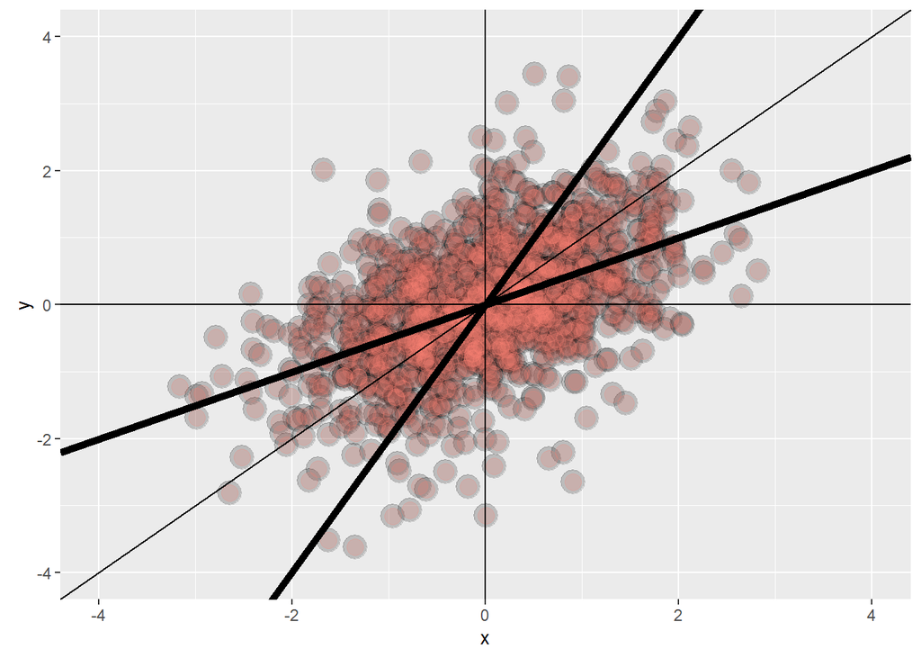

```r
library(ggplot2)
g <- ggplot(data.frame(x = x, y = y), aes(x = x, y = y)) ## Creates 'g', a ggplot variable

# The following two lines set up the point aesthetics of the variable
g = g + geom_point(size = 6, colour = "black", alpha = 0.2)
g = g + geom_point(size = 4, colour = "salmon", alpha = 0.2)

# and them set up the limits of visible graph (if outliers are present, the visuals could be messed up without it)
g = g + xlim(-4,4) + ylim(-4,4)

# The next three lines create graph lines, one vertical, one horizontal and one with the slope = 1, all passing through the origin
g = g + geom_abline(intercept = 0, slope = 1)
g = g + geom_vline(xintercept = 0)
g = g + geom_hline(yintercept = 0)

# These create some a line that using the slope of the correlation and a second one with the inverse of the correlation
g = g + geom_abline(intercept = 0, slope = rho, size = 2)
g = g + geom_abline(intercept = 0, slope = 1/rho, size = 2)
g
```

## Example 2

Below we create variables representing Federal Reserve rates.  
*Obs: Data is available at http://www.federalreserve.gov/release/g19/20050805/*

```r
year <- c(2000,2001,2002,2003,2004)
rate <- c(9.34, 8.50, 7.62, 6.93, 6.60)
```

Now we show the plot representing the previous variables:

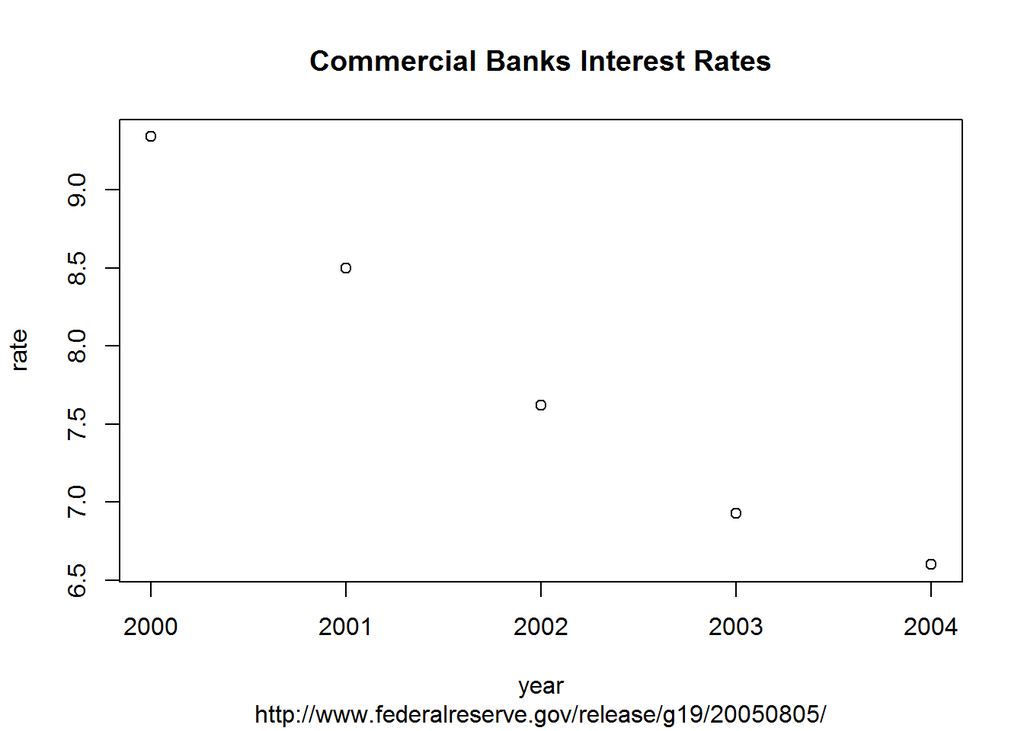

```r
plot(year, rate, main = "Commercial Banks Interest Rates", sub = "http://www.federalreserve.gov/release/g19/20050805/")
```

And now we show the correlation between the two variables:

```r
cor(year, rate)
```

```
## [1] -0.9880813
```

As we can see, the correlatio is close to -1, which in practice, in uncommon.

Now we create the model for rate(dependent variable) to year(independent variable)

```r
fit <- lm(rate ~ year) # The first Variable is the dependent and the second one is the independent
fit
```

```
##
## Call:
## lm(formula = rate ~ year)
##
## Coefficients:
## (Intercept)         year
##    1419.208       -0.705
```

Understanding that composes the fit variable:

```r
attributes(fit)
```

```
## $names
##  [1] "coefficients"  "residuals"     "effects"       "rank"
##  [5] "fitted.values" "assign"        "qr"            "df.residual"
##  [9] "xlevels"       "call"          "terms"         "model"
##
## $class
## [1] "lm"
```

To check how good the model is, we now are going to check the residuals:

```r
res <- rate - (fit$coefficients[[2]]*year+fit$coefficients[[1]])
res
```

```
## [1]  0.132 -0.003 -0.178 -0.163  0.212
```

and we plot the residuals:

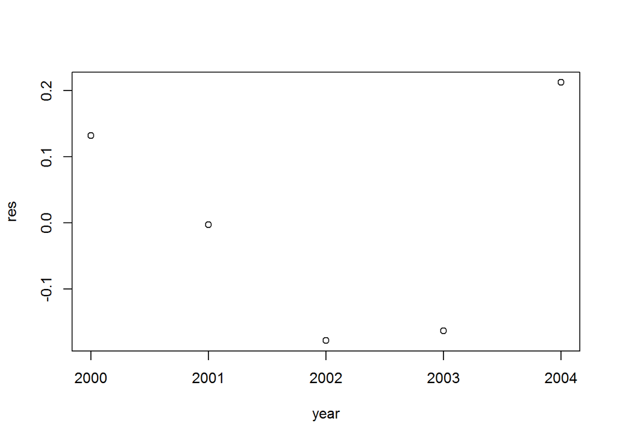

```r
plot(year,res)
```

Here we plot the federal rates with the fit line

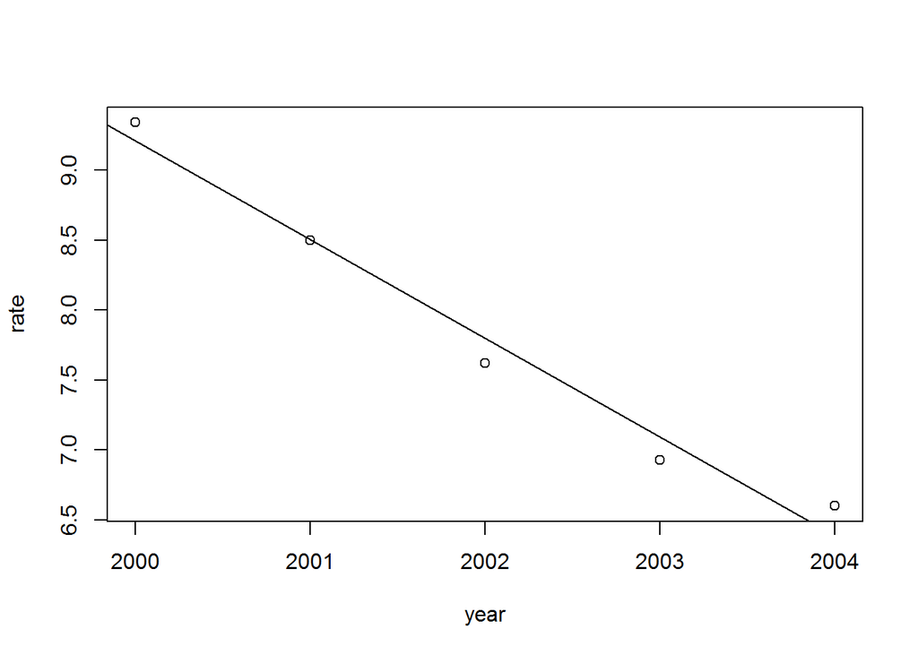

```r
plot(year,rate)
abline(fit)
```

And finally we get a summary on the model

```r
summary(fit)
```

```
##
## Call:
## lm(formula = rate ~ year)
##
## Residuals:
##      1      2      3      4      5
##  0.132 -0.003 -0.178 -0.163  0.212
##
## Coefficients:
##               Estimate Std. Error t value Pr(>|t|)
## (Intercept) 1419.20800  126.94957   11.18  0.00153 **
## year          -0.70500    0.06341  -11.12  0.00156 **
## ---
## Signif. codes:  0 '***' 0.001 '**' 0.01 '*' 0.05 '.' 0.1 ' ' 1
##
## Residual standard error: 0.2005 on 3 degrees of freedom
## Multiple R-squared:  0.9763, Adjusted R-squared:  0.9684
## F-statistic: 123.6 on 1 and 3 DF,  p-value: 0.001559
```